# Tema 1 Introduccion a R

Julia Chacón

14/9/2022

# 1 Introduccion a R

## 1.1 Qué es R

`R` es un lenguaje de programación libre y gratuito, especialmente indicado para análisis estadístico y elaboración de gráficos. Se trata de una versión libre de otro programa que se llama S o S-plus, desarrollado por los Laboratorios Bell. Todo el código de R está disponible como software libre bajo las condiciones de licencia GNU-GPL.

Podéis acceder al proyecto R desde un buscador escribiendo `R project` o visitando directamente su página http://www.r-project.org

## 1.2 Instalación de R

Instalar `R` es fácil, independiente de si usas `Windows`, `Mac` o `Linux`. Basta con ingresar a https://cran.r-project.org/ y seguir las instrucciones de descarga e instalación.

[figure not shown]

Figura 1. Descarga de R desde un buscador

En la página que se abre, debes darle a un link que dice “Download R-3.6.3 for Windows”. Cuando hagas clic, se descargará en tu ordenador un ejecutable que se llama “R-3.6.3-win.exe” (o la versión de R que ofrezca Cran)

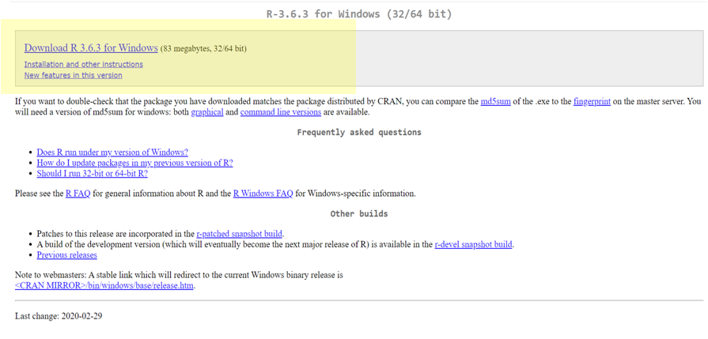

Figura 2. Página de R project desde la cual se realiza la descarga. Debes hacer clic donde pone Download R señalado en amarillo

Haz clic en el ejecutable que has descargado para proceder con la instalación. La instalación es muy sencilla, solamente tienes que ir haciendo “clic” en ” aceptar” o “siguiente” sin modificar ninguna de las opciones que te da por defecto. Lo primero que te pregunta es que selecciones el idioma. Esta opción la puedes cambiar al idioma que tu prefieras. El curso se imparte en español, pero puedes elegir inglés o el idioma que prefieras para el programa.

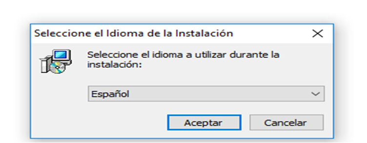

Figura 3. Selecciona el idioma

A continuación tienes las imágenes de los cuadros que se irán abriendo, para que te resulte familiar.

Simplemente haz clic en siguiente:

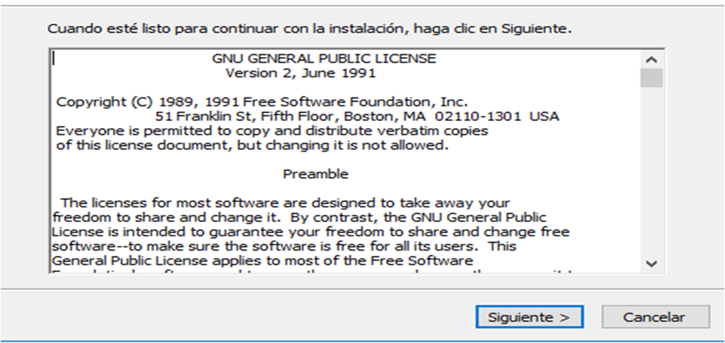

Figura 4. Haz clic en siguiente

Haz clic en siguiente:

[figure not shown]

Figura 5. Haz clic en siguiente

Espera a que se instale el programa en tu sistema:

[figure not shown]

Figura 6. Espera a que termine la instalación

Haz clic en siguiente:

[figure not shown]

Figura 7. Haz clic en siguiente

Cuando llegues a este cuadro, haz clic en finalizar. Ya tendrias `R` instalado en tu ordenador.

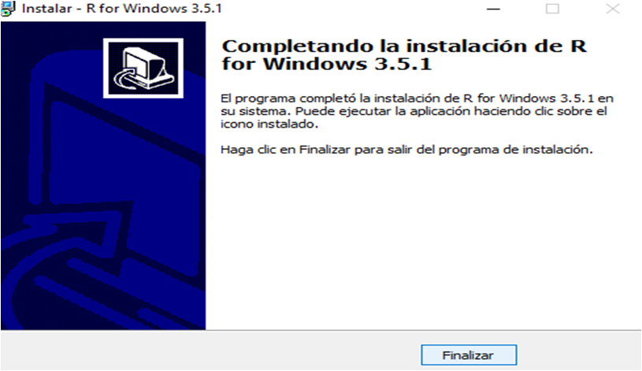

Figura 8. Haz clic en finalizar

## 1.3 Instalación de Rstudio

[figure not shown]

Figura 9. Logo de RStudio

`RStudio` es una plataforma que ayuda a programar con `R`. Es decir, utiliza `R` como lenguaje de programacion. Podemos utilizar `R` con o sin `RStudio`, pero no podemos utilizar `RStudio` sin `R`. El uso que hagamos de esta herramienta es personal, y cada persona decide si quiere utilizarla o no. Nosotros proponemos el uso de `RStudio`, porque nos resulta una herramienta muy util y facilita el uso de `R` y de sus multiples aplicaciones, por lo que el curso lo vamos a desarrollar utilizando `RStudio`.

Para instalar `RStudio`, es necesario tener instalado `R`. La descarga e instalación es accesible en `Windows`, `Mac` y `Linux`. El link es https://www.rstudio.com/products/rstudio/download/#download

[figure not shown]

Figura 10. Descarga de RStudio

## 1.4 Introducción al uso de RStudio

Una vez descargados `R` y `RStudio`, basta con que hagas clic simbolo de RStudio para comenzar a trabajar.

### 1.4.1 Partes de RStudio

Una vez abierto RStudio, observaras una pantalla parecida a la de la Figura 11, conformada por cuatro paneles. Los colores de la pantalla en tu caso, seran diferentes. Mas adelante aprenderemos a cambiarlos. Por ahora fijate en los cuatro paneles que aparecen

[figure not shown]

Figura 11. Interfaz de RStudio. Esta inferfaz se compone por cuatro paneles

#### 1.4.1.1 Consola

En el panel inferior izquierdo de `RStudio` nos encontraoms con la consola. Es la parte principal de `RStudio` y `R` en general. Es el lugar donde escribimos los codigos en lenguaje `R` para dar ordenes al programa. Los codigos tambien pueden llamarse comandos.

Prueba a escribir tu primer comando en la consola:

```r
7+3
```

```
#> [1] 10
```

En la consola siempre aparece el simbolo del prompt `>` Este simbolo nos indica que podemos escribir una orden o comando, porque el programa esta listo para recibir esa orden

#### 1.4.1.2 Códigos o scripts

En el panel superior izquierdo de `RStudio` es donde escribimos los codigos o comandos, en lenguaje `R`, pero esta vez en una especie de cuaderno o bloc de notas para comandos, que podemos guardar para repetir los analisis cuando queramos o compartir nuestros códigos.

Esos archivos se llaman `R Script`. Veremos muchos a lo largo del curso. Para poder abrir nuestro primer `R Script`, tenemos que presionar la pestaña con el simbolo de suma que aparece en la parte superior izquierda, y seleccionar `R Script` (Figura 12). Se abrirá automáticamente un archivo en blanco donde podemos empezar a escribir comandos.

[figure not shown]

Figura 12. Ubicación de los R Script

Otras formas de abrir un nuevo script:

- directamente escribiendo `Crtl + Shift + N`
- en `File > New File > R Script`

En este `R Script`. cada línea representa un comando. Para que una línea que escribimos ahí se ejecute debemos presionar `Ctrl + Enter` (En Mac, `Cmd + Enter`). Puedes seleccionar varias líneas a la vez y correrlas juntas presionando `Ctrl + Enter`

Podemos poner comentarios explicativos en un código de R simplemente escriendo el símbolo del numeral `#` delante del código. Todo texto que presente este símbolo `#` delante, no se ejecuta, y se considera un comentario.

```r
7+3  # Esto es un comentario. R sólo correrá el código hasta el símbolo #
```

```
#> [1] 10
```

Los R Scripts se guardan:

- Presionando `Ctrl + S`
- `File > Save`

#### 1.4.1.3 Environment o sesión

En la parte superior derecha de la consola hay varias pestañas: Environment, History y Connections. La más importante es la pestaña Environment, en ella aparecerán los “objetos” que vayamos creando a medida que trabajamos. R almacena objetos, con los que luego podemos realizar otras operaciones.

Veamos un ejemplo, aunque más adelante entenderemos lo que son los objetos. Escribe en tu consola lo siguiente:

```r
cosa <- 2 + 3 # podemos almacenar la suma 2 + 3 en forma de un objeto que se llama "cosa"

cosa # si ahora escribes "cosa" en tu consola, aparece directamente el resultado de la suma.
```

```
#> [1] 5
```

```r
# Puedes comprobar cómo ahora "cosa" es un objeto que queda almacenado en Environment
```

Para asignar un valor a un objeto se utiliza la flecha `<-` La forma correcta de utilizarlo sería `nombre_de_lobjeto <- contenido_asignado`

Más adelante trabajaremos los objetos, de momento sólo quiero que veas que se almacenan en tu `Environment` y que eso te permite consultarlos más adelante.

Otra pestaña interesante es History. Se trata de un historial, donde aparecen todos los comandos que has escrito durante la sesión de R en la cuál estás trabajando. Te permite recuperar códigos que has perdido o consultar qué has estado haciendo

#### 1.4.1.4 Directorio, Gráficos, Paquetes y Ayuda

En la parte inferior derecha de `RStudio` aparecen varias pestañas de nuevo: File, Plots, Packages, Help, Viewer. File es simplemente el directorio de trabajo donde te encuentras trabajando, es decir, la carpeta dónde estás trabajando y todos los archivos que en ella se encuentran guardados.

La pestaña Plots es donde aparecerán las figuras que hagamos. En Packages aparecen los paquetes descargados. Help es una pestaña de consulta o ayuda. No te preocupes, iremos viendo todas las funcionalidades de RStudio a lo largo del curso, de forma intuitiva y natural.

## 1.5 Instalar y cargar paquetes

Los paquetes de R son colecciones de funciones y datos que guardan algún tipo de relación entre sí.

R tiene un sistema que se denomina “base”, que contiene funciones básicas para análisis estadístico y visualización. Pero además de estas funciones básicas podemos extender la funcionalidad de R con los paquetes que hacen trabajos más específicos. Por ejemplo, existen paquetes para visualización de datos como ggplot2, para análisis geoespacial, analisis de datos ecologicos, para organizar datos, y para muchísimas cosas más.

Los paquetes de `R` se encuentran alojados en `CRAN` (https://cran.r-project.org/), donde pasan controles antes de estar disponibles para el uso general.

Existe la opción de crear tus propios paquetes, cuando tienes colecciones propias de funciones que quieres almacenar y compartir con el resto de la comunidad.

Podemos instalar paquetes de diferentes formas.

Una es utilizando la función `install.packages()`. El nombre del paquete que queremos instalar debe ir entre comillas. Una vez instalado el paquete, la función que nos permite cargar esa librería se llama `library()`. Veamos algunos ejemplos y otras funciones que pueden ser interesantes.

```r
install.packages("vegan") # Para instalar un paquete

library(vegan) # sirve para cargarlo en la sesión de R en la que estamos trabajando.

(.packages()) # proporciona una lista de los paquetes cargados en este momento

(.packages(all.available=TRUE)) # Devuelve la lista de paquetes disponibles

# Podemos tratar de cargar la librería tree
library (tree)  # pero este comando no funciona porque no está en nuestra lista de paquetes disponibles

install.packages("tree") # Debemos instalar el paquete primero, y después cargarlo
library(tree)#  ahora sí lo podemos cargar y no da error

remove.packages("vegan") # elimina este paquete

(.packages(all.available=TRUE)) # Puedes comprobar que ya no aparece en la lista de paquetes disponibles
```

También podemos instalar paquetes utilizando el menú de `RStudio`: Tools > Install packages…

O desde el panel de abajo a la derecha de `RStudio`: Packages/Install. Nos permite ver los paquetes que tenemos actualmente instalados y aquellos que se encuentran cargados.

[figure not shown]

Figura 14. Lista de paquetes instalados

# 2 Una primera aproximación al lenguaje de programación

Una vez instalados R y Rstudio, podemos abrir el programa haciendo doble clic sobre el icono de Rstudio. De momento utilizaremos solo la consola. La consola es la herramienta principal del programa, donde nosotros vamos a escribir comandos y ejecutar operaciones.

En la parte de arriba de la consola, al inicio, siempre aparece informacion basica del programa, por ejemplo, la version de R que estamos utilizando.

Al comienzo de la linea de comando siempre aparece este simbolo `>`

Cuando vemos este simbolo, significa que el programa esta esperando a que escribamos una orden.

Podemos ejecutar una suma:

```r
2+2
```

```
#> [1] 4
```

El símbolo de numeral `#` es utilizado para hacer comentarios:

```r
#  3 + 4
```

Como véis no ocurre nada.

El uso más sencillo que se le puede dar a R es el de una calculadora. Consideremos las siguientes operaciones:

- Adición: `+`
- Resta: `-`
- Multiplicación: `*`
- División: `/`
- Exponenciación: `^`
- Módulo: `%%`

Los últimos dos necesitan una breve explicación:

- El operador `^` eleva el número a la izquierda a la potencia a la derecha `3^2` es 9
- El módulo (mod) `%%` calcula el residuo de la división del número a la izquierda por el número a la derecha, por ejemplo 5 mod 3 o `5%%3` es 2.

Ejemplos:

Adiciones y restas:

```r
2+3+4+5-6
```

```
#> [1] 8
```

Si se presiona Enter antes de tiempo, el programa nos permite terminar la operacion en la siguiente.

```r
2+3+4+5-
  6
```

```
#> [1] 8
```

Multiplicación:

```r
2*4
```

```
#> [1] 8
```

División:

```r
2/4
```

```
#> [1] 0.5
```

Combinación de operaciones:

```r
2+3*6
```

```
#> [1] 20
```

Utilizando los paréntesis se puede indicar el orden de las operaciones:

```r
(2+3)*6
```

```
#> [1] 30
```

```r
(2+3)/6
```

```
#> [1] 0.8333333
```

```r
2+3/6
```

```
#> [1] 2.5
```

Otros: exponencia, logaritmo, raíz cuadrada…

```r
6^2
```

```
#> [1] 36
```

```r
log(10)
```

```
#> [1] 2.302585
```

```r
sqrt(4)
```

```
#> [1] 2
```

# 3 Aprender a cargar y guardar datos.

## 3.1 Lectura e importación de datos

Para poder proceder con un análisis de datos, debemos cargar los datos en `R`. En este tutorial aprenderemos a importar y exportar datos en diferentes formatos. Hemos seleccionado los más comunmente utilizados.

Podemos importar en formato texto o tabulares desde un archivo `.txt` o `.csv` Podemos importar directamente desde Excel, archivos `.xls` o `.xlxs` También existen formatos propios de R, como los `.Rdata` o `.rda` y los serialized `R` objects `.rds`

Durante este tutorial vamos a utilizar de nuevo el conjunto o set de datos `iris`. Este conjunto de datos, como vimos en el video anterior, contiene datos sobre características florales de tres especies del género Iris.

Vamos a cargar el conjunto de datos `iris`, y a explorarlo brevemente antes de continuar. Para cargarlo utilizaremos la función `data()`, y lo exploraremos utilizando la función `head()` que nos permite visualizar las primeras 6 filas. También vamos a introducir nuevas funciones que nos permitirán explorar el conjunto de datos iris: `dim()` `colnames()` y `tail()`

```r
data(iris)# para cargar los datos
?iris # consulta sobre el data set
head(iris) # muestra las primeras 6 filas de un data set
head(iris, n = 10)
dim(iris) # dimensiones del data set iris
tail(iris) # muestra las ultimas 6 filas de un data set
colnames(iris)# la funcion colnames() nos muestra los nombres de las variables de iris
names(iris) # la funcion names() nos muestra los nombres de las variables de iris
```

## 3.2 Importar datos desde .csv

`CSV` significa “comma separated data”. El formato `.csv` es un caso particular de “tabular data” o “text data”

Vamos a practicar la siguiente secuencia: (1) EXPORTAR los datos `iris` en formato `.csv` en nuestro directorio de trabajo, (2) ELIMINAR los datos `iris` de nuestra sesión, (3) volver a IMPORTAR los datos `iris` desde nuestro directorio de trabajo.

Para exportar `iris` a un fichero en formato `CSV` utilizaremos la función `write.csv()`. Debemos indicar el objeto que queremos exportar, en este caso será la colección de datos `iris`, y el nombre que queremos que tenga el archivo que generamos en nuestro directorio de trabajo.

```r
write.csv(iris, file = "iris.csv")
```

Cuando trabajamos con proyectos es útil tener una carpeta exclusiva para datos, otra para codigo, otra para figuras, que nos faciliten la organización de nuestro trabajo. Por lo que vamos a guardar el `iris.csv` en la carpeta de datos de nuestro proyecto `iris`

```r
write.csv(iris, file = "datos/iris.csv")
```

Para importar los datos podemos hacer dos cosas, eliminarlos de la sesión y luego volverlos a importar. O simplemente importarlos con un nombre diferente. Vamos primero a importarlos con un nombre diferente. La importación se realiza con la función `read.csv`. Recuerda, que debemos asignar la importación a un objeto, para que los datos se queden guardados en la sesión. Lo llamaremos `iris_import_csv`, y solamente deberíamos indicar la ruta donde se encuentran los datos

```r
iris_import_csv <- read.csv("datos/iris.csv")
```

Te propongo como ejercicio que borres los dos objetos, `iris` y `iris_import_csv` de la sesión, y los importes directamente desde nuestro directorio de trabajo. Te doy una pista, tendrás que utilizar la función `rm()` que vimos previamente y la función `read.csv()`

## 3.3 Importar datos desde Excell

Importar datos desde Excell es muy parecido a la importación de datos desde `.csv`. Las funciones que utilizaremos son `write.xlsx()` para la exportación y `read.xlsx()` para la importación. Debemos instalar primero el paquete `xlsx`

```r
install.packages("xlsx")
library(xlsx)
write.xlsx(iris, "datos/iris.xlsx")  # acuerdate que los vamos a guardar en la carpeta datos
iris_import_xlsx <- read.xlsx("datos/iris.xlsx", 1) # debemos indicar la hoja de Excell desde la cual importar los datos
```

## 3.4 Formatos propios de R

Existen formatos propios de `R` para guardar datos, sesiones y objetos concretos que hemos generado sin necesidad de recurrir a formatos `.txt`, `.csv`, o a `Excell`. Guardar los datos como objetos de `R` es muy util porque permite guardar la estructura de datos que nosotros generamos en `R` para nuestros análisis. Esa estructura se pierde cuando guardamos en formatos diferentes a los propios de `R`.

Por ejemplo, nosotros definir las columnas de un set de datos en `R` como factor, integer, como character… al exportarlo esa estructura interna se perderá. Por eso es importante que una vez que estemos trabajando en los datos, los guardemos en formatos propios de `R`. Podemos reservar los otros formatos para almacenamiento de nuestros datos originales o “crudos” (del inglés “raw”).

### 3.4.1 Rdata

Permite guardar una sesión completa, o seleccionar determinados objetos dentro de una sesión.

Podemos guardar toda la sesión de trabajo con `save.image()`

```r
save.image(file="datos/toda_la_sesion.RData")
```

También podemos guardar objetos concretos son `save()` pero tienes que indicar qué objetos de tu sesión quieres que guarde.

```r
save(iris, file="datos/iris_object_only.RData")
```

También puedes cargarlos después con `load()` (puedes limpiar tu sesión antes para comprobar que funciona bien)

```
load("datos/iris_object_only.RData")
```

Puedes cargar los datos con `load()` o también desde el menú de `RStudio` File > Open File

### 3.4.2 RDS

El formato `.rds` nos permite guardar solamente un unico objeto, y la otra diferencia con un `.Rdata` es que no conserva el nombre de los objetos originales. Esto es una ventaja en muchas ocasiones, cuando estamos importando objetos y no queremos que nos limiten los nombres originales que les pusimos.

Para exportar `iris` a formato RDS utilizamos la función `write_rds()`. Hay que indicarle un `path`. También debemos instalar el paquete `readr` previamente.

```r
install.packages("readr")
library(readr)
write_rds(iris, path="datos/iris.rds")
```

Para leer o importar datos `RDS` utilizamos la función `readRDS()` y asignarle un nombre al objeto que vayamos a crear:

```r
iris_import_rds <- readRDS("datos/iris.rds")
```

# 4 Manejo de directorios

## 4.1 Qué es un directorio

Un directorio de trabajo es simplemente la carpeta o lugar de nuestro ordenador donde se encuentran ubicados los archivos con los que vamos a trabajar en `R`. Es decir, ahí estarán ubicados los datos que después importaremos en nuestra sesión de R. También es el lugar donde guardaremos nuestros códigos, exportaremos figuras y cualquier otro elemento que exportemos durante la sesión de trabajo.

## 4.2 Ubicación y cambios de directorio

Para conocer dónde está ubicado el directorio de trabajo utilizamos la función `getwd()`. Solamente se escribe en la consola y se ejecuta.

```r
getwd() # consultar dónde se ubica el directorio de trabajo
```

```
#> [1] "C:/Users/34685/Documents/GitHub/UAMBioDivR/Bloque 1"
```

Podemos cambiar el directorio de trabajo de diferentes maneras.

Con la función `setwd()`. Habría que indicar la ruta donde se localiza el directorio de trabajo.

```r
setwd("C:\midirectorio")
```

También podemos indicar el directorio utilizando el menú de `RStudio`: Session > Set Working Directory > Choose Directory

Otras funciones interesantes son `list.files()` y `list.dir()`.

La función `list.files()`, sin especificar ningún argumento, nos muestra una lista con los nombres de todos los archivos que hay dentro del directorio de trabajo. La función `dir()` hace exactamente lo mismo

La función `list.dirs()`, sin especificar ningún argumento, nos muestra una lista de los directorios dentro del directorio de trabajo.

```r
# Ver archivos
list.files()
```

```
#> [1] "basurita"
#> [2] "images"
#> [3] "miprimerasesion.RData"
#> [4] "Tema-1-Introduccion-general-I.html"
#> [5] "Tema-1-Introduccion-general-I.Rmd"
#> [6] "Tema-1-Introduccion-general-II.html"
#> [7] "Tema 1 Introduccion general I.Rmd"
#> [8] "Tema 1 Introduccion general II.Rmd"
#> [9] "Tema 2 Manejo y filtrado de datos.Rmd"
```

```r
dir()
```

```
#> [1] "basurita"
#> [2] "images"
#> [3] "miprimerasesion.RData"
#> [4] "Tema-1-Introduccion-general-I.html"
#> [5] "Tema-1-Introduccion-general-I.Rmd"
#> [6] "Tema-1-Introduccion-general-II.html"
#> [7] "Tema 1 Introduccion general I.Rmd"
#> [8] "Tema 1 Introduccion general II.Rmd"
#> [9] "Tema 2 Manejo y filtrado de datos.Rmd"
```

# 5 Organizar el trabajo: sesiones, proyectos y más…

## 5.1 Sesiones

### 5.1.1 Qué es una sesión

Cada vez que ejecutamos o abrimos `R` (o `RStudio`) estamos iniciando una sesión. Todos los objetos y funciones que generemos durante esa sesión se almacenan en la memoria RAM de nuestro ordenador. Es decir, esos objetos y funciones que creamos permanecen únicamente en nuestra sesión.

Cuando cerramos una sesión, por ejemplo de forma fortuita, los objetos almacenados en esa sesión se pierden. Para no perderlos debemos guardar la sesión en un archivo que tiene una extensión `.Rdata`. Ese archivo quedaría guardado en nuestro directorio de trabajo y disponible para la próxima sesión.

### 5.1.2 Cómo guardar una sesión

También podemos guardar la sesión con la función `save.image()`. Veamos un ejemplo. Primero vamos a cargar una colección de datos que están disponibles en `R` con la función `data()`. Son los datos `iris`, muy conocidos porque se utilizan como ejemplo en muchos tutoriales de `R`.

```r
data("iris") # cargamos el set de datos iris
```

Vemos que ahora ha aparecido un objeto en la pestaña `Environment` que se llama `iris`. Podemos explorar un poco este objeto con la función `head()` que nos mostrará las primeras 6 filas de ese set de datos y los nombres de las columnas.

```r
head(iris) # exploremos rápidamente el set de datos iris
```

```
#>   Sepal.Length Sepal.Width Petal.Length Petal.Width Species
#> 1          5.1         3.5          1.4         0.2  setosa
#> 2          4.9         3.0          1.4         0.2  setosa
#> 3          4.7         3.2          1.3         0.2  setosa
#> 4          4.6         3.1          1.5         0.2  setosa
#> 5          5.0         3.6          1.4         0.2  setosa
#> 6          5.4         3.9          1.7         0.4  setosa
```

```r
ls()
```

```
#> [1] "cosa" "iris"
```

Si ahora cerramos nuestra sesión, perderíamos el objeto `iris`. Podemos guardar la sesión en un archivo con extensión `.Rdata` en nuestro directorio de trabajo con la función `save.image()`.

```r
save.image(file="miprimerasesion.RData")
```

Si te fijas ahora en tu directorio de trabajo, en `Files`, ha aparecido un archivo que se llama `miprimerasesion.Rdata`. Ese archivo contiene todos los objetos que has creado durante la sesión.

### 5.1.3 Notas:

Podemos tener tener más de una sesión de R activa en la misma computadora.

Podemos tener sesiones que compartan un mismo directorio de trabajo

Los objetos y funciones de una sesión son exclusivos de esa sesión. No se comparten entre sesiones.

Los códigos se guardan en el directorio de trabajo, no es una sesión. Si no los guardas de forma separada los perderás al cerrar la sesión.

Se pueden eliminar todos los objetos de una sesión con la función `ls()`

```r
rm(list=ls())  # elimina todos los objetos de una sesión
```

## 5.2 Rprojects o proyectos de R

Los proyectos de R o `Rproject` son una forma elegante y muy práctica de gestionar tus análisis de datos. Algunas ventajas son que facilitan compartir los análisis y la gestión de los proyectos de análisis que tengas en marcha.

Cada `Rproject` tiene su propio directorio de trabajo, su propia sesión o espacio de trabajo (environment), su historial de análisis. Lo más interesante es que permite crear una estructura de carpetas donde guardar los documentos asociados al proyecto en carpetas separadas (p.ej: una carpeta para datos, otra para figuras, otra para códigos…).

Cuando trabajamos desde un `Rproject` en `RStudio` ocurre que:

- Comienza una nueva sesión de `R`
- El directorio de trabajo se fija a la carpeta que contiene el `Rproject`.

Siempre que estemos trabajando en un proyecto que requiera una estructura de subcarpetas, merece la pena gestionarlo a través de un `Rproject`.

# 6 Estrategias de búsqueda de ayuda

En muchas ocasiones necesitaremos ayuda sobre los argumentos o funcionamiento de una función concreta, o simplemente porque nos encontramos frente a un error. Lo más común es llamar a la función de ayuda de `R` que es `help()`

La función`help()` nos permite pedir ayuda sobre funciones concretas. Ejemplo sobre pedir ayuda de la función genérica `plot()`:

```r
help(plot)
?plot
```

También podemos buscar ayuda sobre un paquete concreto, ejemplo con el paquete ggplot2:

```r
install.packages("ggplot2") # Instalar ggplot2
library(ggplot2)  # Cargar ggplot2
library(help= "ggplot2") # Pedir ayuda sobre el paquete ggplot2
```

Tambien existen las vignettes, que son unos tutoriales especificos que en ocasiones acompañan a los paquetes.

```r
vignette() # Proporciona una lista de vignettes a las que podemos acceder
vignette(package="ggplot2") # Proporciona una lista de vignettes a las que podemos acceder para ggplot2
vignette("ggplot2-specs", package="ggplot2") # acceso a una vignette concreta de ggplot2
```

Y por supuesto, existen infinidad de recursos en internet. En el siguiente apartado te proponemos muchas webs y comunidades de ayuda.

## 6.1 Otros recursos y comunidades de ayuda

### 6.1.1 Páginas generales

[Libro de recetas](http://www.cookbook-r.com/)

[R pubs](http://rpubs.com/)

[R bloggers](https://www.r-bloggers.com/)

[R for stats](http://r4stats.com/)

[Data camp](https://www.datacamp.com/)

[R open science](https://ropensci.org/)

[Revolution analytics](https://blog.revolutionanalytics.com/)

### 6.1.2 Libros online y físicos

[Modelos estadísticos de Ben Bolker](https://ms.mcmaster.ca/~bolker/emdbook/)

[Programación eficiente](https://csgillespie.github.io/efficientR/introduction.html)

[R for data science de Hadley Wickham](https://r4ds.had.co.nz/)

[R avanzado de Hadley Wickham](https://adv-r.hadley.nz/)

[ggplot](https://www.springer.com/us/book/9780387981413)

[Gramática de gráficos](https://www.amazon.es/dp/B00HWUVHXK/ref=dp-kindle-redirect?_encoding=UTF8&btkr=1)

Libro de recetas

[The R book](https://www.cs.upc.edu/~robert/teaching/estadistica/TheRBook.pdf)

[RMarkdown](https://bookdown.org/yihui/rmarkdown/)

[Tablas con RMarkdown y KableExtra](https://cran.r-project.org/web/packages/kableExtra/vignettes/awesome_table_in_html.html#installation)

[Citas bibliográficas con RMarkdown](http://vivaelsoftwarelibre.com/insertar-referencias-bibliograficas-en-r-markdown/)

[R para ecólogos](https://www.springer.com/us/book/9780387898810)

### 6.1.3 Ayuda general

[R podcast](https://r-podcast.org/)

[Repositorio de chuletas](https://www.rstudio.com/resources/cheatsheets/)

### 6.1.4 Visualizacion de datos

[Página oficial de ggplot](https://ggplot2.tidyverse.org/)

[Galería de gráficos](https://www.r-graph-gallery.com/)

[Recetas/parte de gráficas](http://www.cookbook-r.com/Graphs/)

### 6.1.5 Estadística básica

[Estadística básica](https://www.statmethods.net/stats/index.html)

[Tutoriales de introducción](http://www.r-tutor.com/elementary-statistics)

[R4stats](http://r4stats.com/)

[Estadística avanzada](http://www.sthda.com/english/wiki/r-basic-statistics)

### 6.1.6 Genética

[Bioconductor](https://www.bioconductor.org/)

[Genética de poblaciones](https://popgen.nescent.org/)

### 6.1.7 Ecología

[Vegan](https://rdrr.io/rforge/vegan/man/vegan-package.html)

[ADE4](http://pbil.univ-lyon1.fr/ade4/home.php?lang=eng)

### 6.1.8 Cuentas populares de Twitter

> "R cambió mi opinión sobre el género humano al observar cuántas personas están realmente dispuestas a participar en actividades colectivas, buscando algo que trasciende a sus propios intereses. Se realizan muchas actividades sin que haya un reconocimiento individual."  
> Ross Ihaka [pic.twitter.com/lx0vUCXdHW](https://t.co/lx0vUCXdHW)

> — Rosana Ferrero (@RosanaFerrero) [30 de octubre de 2018](https://twitter.com/RosanaFerrero/status/1057212329270673408?ref_src=twsrc%5Etfw)

> ¿Cómo ser un usuario de [#R](https://twitter.com/hashtag/R?src=hash&ref_src=twsrc%5Etfw) resiliente?  
> Interesante presentación provista por [@ma_salmon](https://twitter.com/ma_salmon?ref_src=twsrc%5Etfw) con tips que nos ayudarán a no desistir en el proceso de aprendizaje de este lenguaje. Al final siempre vendrán grandes recompensas.https://t.co/ilsYcx2Y0K[#rstats](https://twitter.com/hashtag/rstats?src=hash&ref_src=twsrc%5Etfw) [#DataScience](https://twitter.com/hashtag/DataScience?src=hash&ref_src=twsrc%5Etfw) [#dataviz](https://twitter.com/hashtag/dataviz?src=hash&ref_src=twsrc%5Etfw) [pic.twitter.com/HlZm2MyAFo](https://t.co/HlZm2MyAFo)

> — tipsder (@tipsder) [2 de noviembre de 2018](https://twitter.com/tipsder/status/1058367762060505089?ref_src=twsrc%5Etfw)

> Does including emoji in your RMarkdown make you go 😦😫😱? Struggle no more: https://t.co/wgCTnsgVAn emo::ji("celebrate") 🎉 [#rstats](https://twitter.com/hashtag/rstats?src=hash&ref_src=twsrc%5Etfw)

> — Hadley Wickham (@hadleywickham) [25 de abril de 2017](https://twitter.com/hadleywickham/status/856938704748896258?ref_src=twsrc%5Etfw)

> Just published: Reproducible science - what, why, how https://t.co/AuFeMPK1bw [#reproducibility](https://twitter.com/hashtag/reproducibility?src=hash&ref_src=twsrc%5Etfw) [pic.twitter.com/dAXShbilBJ](https://t.co/dAXShbilBJ)

> — F Rodriguez-Sanchez (@frod_san) [23 de agosto de 2016](https://twitter.com/frod_san/status/768041676497620992?ref_src=twsrc%5Etfw)

> Like super specific [#NBA](https://twitter.com/hashtag/NBA?src=hash&ref_src=twsrc%5Etfw) stats? Like getting data right in [#rstats](https://twitter.com/hashtag/rstats?src=hash&ref_src=twsrc%5Etfw)? 🏀[@abresler](https://twitter.com/abresler?ref_src=twsrc%5Etfw)'s made like a whole BUNCH of your [hoop] dreams come true…  
> 📦 "nbastatR: R's interface to NBA data" https://t.co/UMaLbh24B6 (seriously, you don't even have to assign names!! 😵) [pic.twitter.com/5V8ZQdAdjO](https://t.co/5V8ZQdAdjO)

> — Mara Averick (@dataandme) [3 de noviembre de 2018](https://twitter.com/dataandme/status/1058740421877288962?ref_src=twsrc%5Etfw)

> First module of SQL basics at [@udacity](https://twitter.com/udacity?ref_src=twsrc%5Etfw) completed. It’s a relief to have learnt R and Java before. I’m advancing very quickly!

> — Pablo Herrera (@pherreraariza) [26 de octubre de 2018](https://twitter.com/pherreraariza/status/1055774343765127168?ref_src=twsrc%5Etfw)